# Graphics in R

## Data Visualization

From Wikipedia:

“R is a programming language and free software environment for statistical computing and **graphics** … .”

There are three major graphical systems:

- `R base graphics`
- `lattice`
- `ggplot2`

In this course we will focus on `ggplot2`. If you want to learn about the other two, [R Graphics](https://www.crcpress.com/R-Graphics/Murrell/p/book/9780429196119) is a great source.

## ggplot2

What is **ggplot2**?

- an R package for data vizualisation
- implementation of the [Grammer of Graphics](https://www.springer.com/de/book/9781475731002) in R
- part of the tidyverse

Some interesting links:

- [R for Data Science](http://r4ds.had.co.nz/)
- [ggplot2: Elegant graphics for data Analysis](http://moderngraphics11.pbworks.com/f/ggplot2-Book09hWickham.pdf)
- [Cookbook](http://www.cookbook-r.com/Graphs/)
- [R Graph Gallery](https://www.r-graph-gallery.com/)
- [DataCamp course](https://www.datacamp.com/courses/data-visualization-with-ggplot2-1)

## The grammer of graphics

- data: in ggplot2, data must be stored as a data.frame
- aesthetics: describe visual characteristics
  - e.g., position (x and y), size, color, shape, fill, …
- geoms: describe type of geometric objects
  - e.g., points, lines, polygons, …
- stats: describe statistical transformations that summarize the data
  - e.g., counts, regression lines, …
- scales: for each aesthetic, describe how visual characteristic is converted to display values
  - e.g., x and y scales, color scales, size scales, shape scales, …
- facets: describe how the data is split into subsets and displayed as multiple small graphs
- coords: describes 2-D space that the data is projected onto
  - e.g., Cartesian coordinates, polar coordinates, map projections, …

## A basic example

```r
library(ggplot2)
data("diamonds")
ggplot(data = diamonds) + geom_point(mapping = aes(x = carat, y = price))
```

`ggplot()`

- creates a coordinate system that you can add layers to

`geom_point()`

- adds a layer of points
- each geom function takes a mapping argument, which paired with `aes()` defines how variables in your dataset are mapped to visual properties

## A basic example

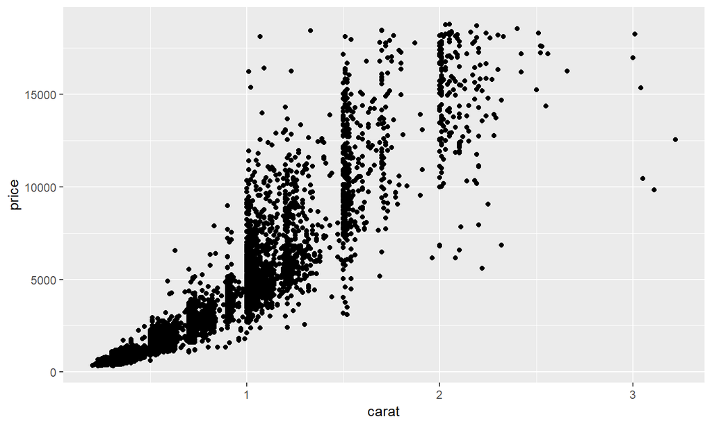

## Adding a layers

- To make the pattern in the data more visible we add a smoothing function to the plot

```r
ggplot(data = diamonds) +
  geom_point(mapping = aes(x = carat, y = price)) +
  geom_smooth(mapping = aes(x = carat, y = price), method = 'loess')
```

- to write more compact code we can leave out the parameter names and switch `mapping` to `ggplot()`
- the same mapping is then used for all layers (but can be overwritten if necessary)

```r
ggplot(diamonds, aes(carat, price)) +
  geom_point() +
  geom_smooth(method = 'loess')
```

## Adding a layers

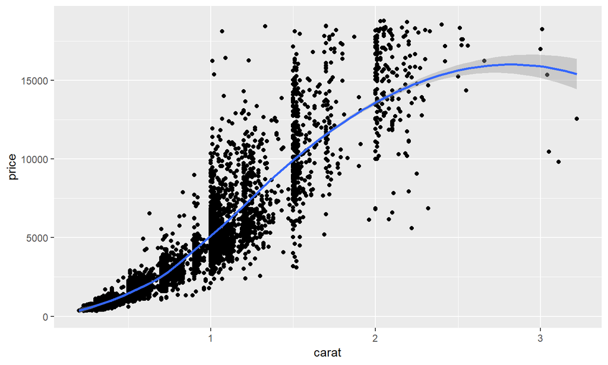

## Aesthetics

- until now we only used the x and y coordinates as aesthetics
- `?geom_point()` tells us about further aesthetics that we can map data to
- note that each geom has its own set of aesthetics

```r
ggplot(diamonds, aes(x = carat, y = price, color = color, shape =  cut)) +
  geom_point()
```

## Aesthetics

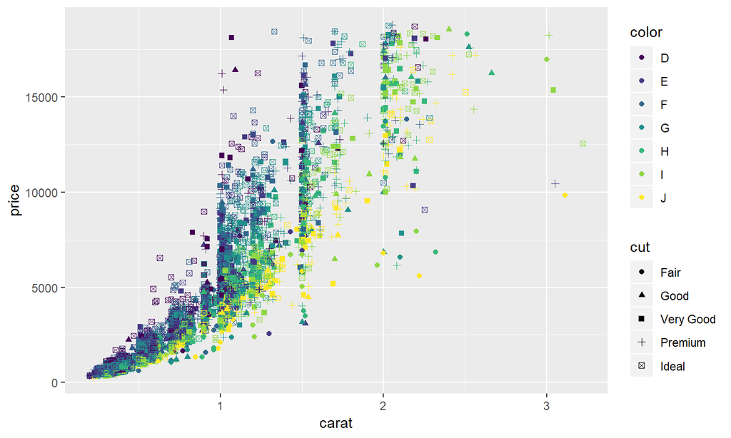

## Statitic Transformations and Aesthetics

- if we map aesthetics to discrete variables, then ggplot will automatically group the data accordingly
- in this case every statistic transformation is performed by group
- you can see what this means by the following example

```r
ggplot(diamonds, aes(x = carat, y = price, color = color, shape =  cut)) +
  geom_point() +
  geom_smooth()
```

## Statitic Transformations and Aesthetics

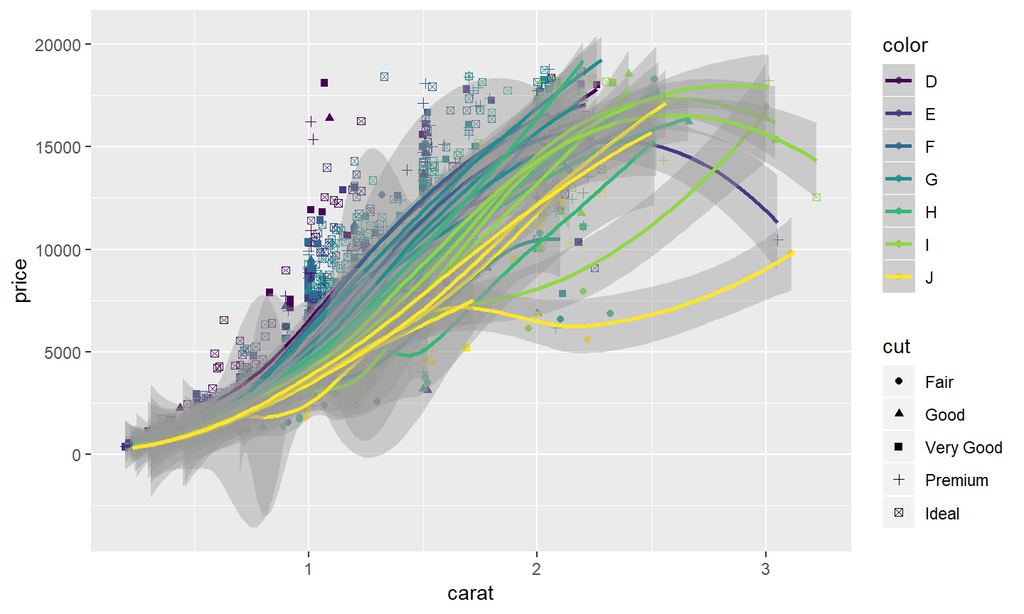

## Statitic Transformations and Aesthetics

- If this is not desired simply move color and shape as additional aesthetics to `geom_point()`

```r
ggplot(diamonds, aes(x = carat, y = price)) +
  geom_point(aes(color = color, shape = cut)) +
  geom_smooth()
```

- in some circumstances it might also be convinient to leave all aesthetics in `ggplot()` (e.g. if there are many layers) and overwrite the created groups by a arbitrary constant value

```r
ggplot(diamonds, aes(x = carat, y = price, color = color, shape = cut)) +
  geom_point() +
  geom_smooth(aes(group = 1))
```

## Statistic Transformations and Aesthetics

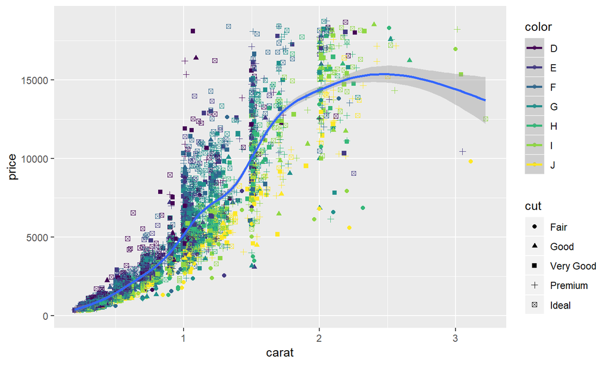

## Geometric Objects ans Statistic transformations

- we can define a new layer in terms of a geometric object (`geom_...`) or a statistic transformation (`stat_...`)
- each geometric object is associated with a default statistic transformation and vice verse
- e.g. `geom_point()` has the indentity function as statistic transformation and `geom_smooth()` fits a regression model before plotting a line with a prediction interval
- there is is an alias function `stat_smooth()` which does esentially the same, however, in the first case we could change the statistic transformation and in the second case we could change the geometric object
- most of the time it is not I good idea to change the default behaviour (e.g. try `geom_point(stat = "smooth", method = "lm")`) but we will see an example where it can be useful

## Bar plot

`geom_bar()` counts the number of observations with within each group

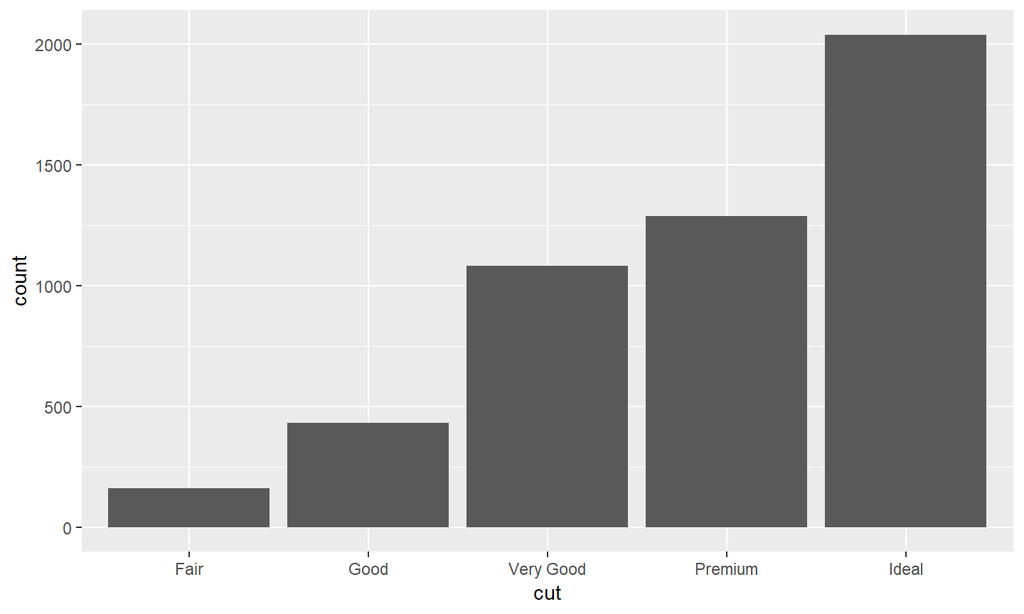

```r
ggplot(data = diamonds) +
  geom_bar(mapping = aes(x = cut)) # x should be discreate
```

## Histogram

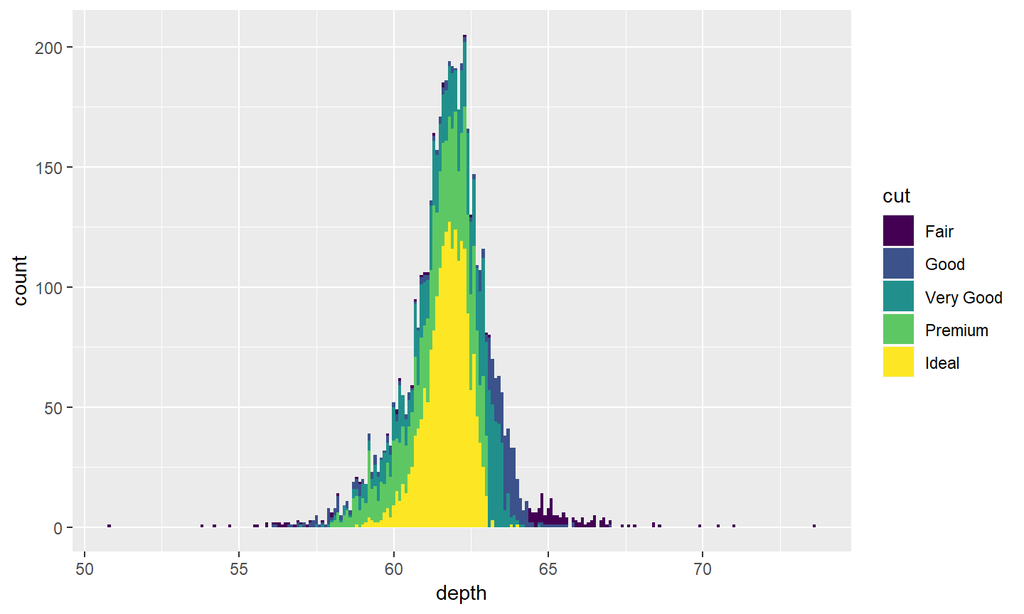

```r
ggplot(diamonds, aes(x = depth, fill = cut)) +
  geom_histogram(binwidth = 0.1)
```

## 1D Density

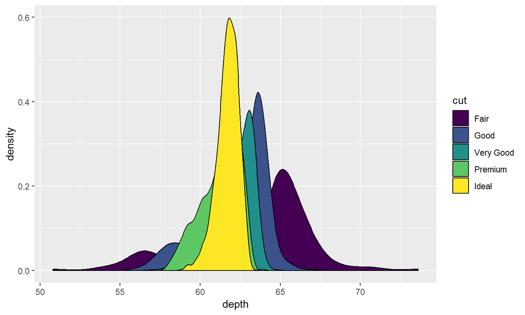

```r
ggplot(diamonds, aes(x = depth, fill = cut)) + # try color instead of fill
  geom_density()
```

## 2D Density

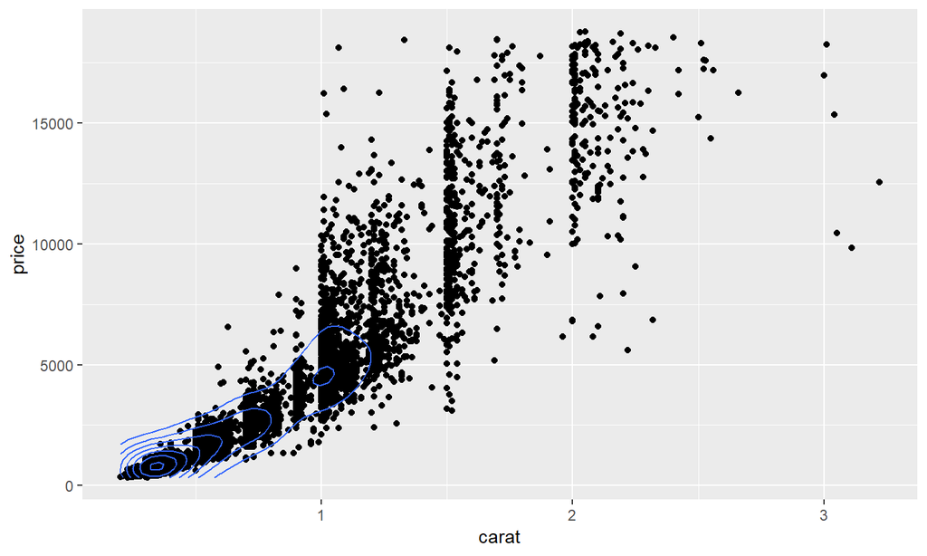

```r
ggplot(data = diamonds, mapping = aes(carat, price)) +
  geom_point() +
  geom_density2d()
```

## 2D Density with geom = “polygon”

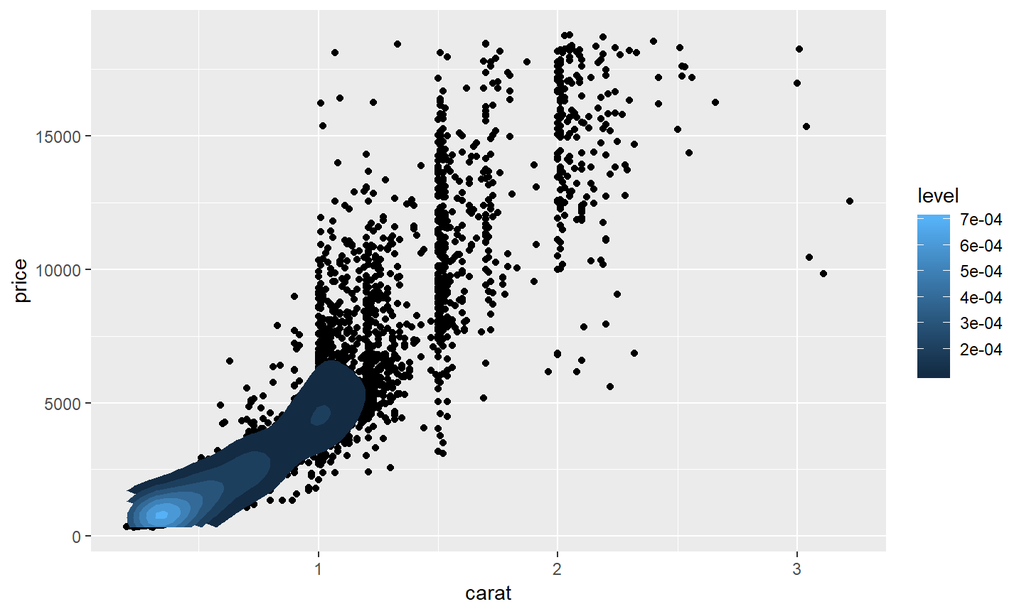

```r
ggplot(data = diamonds, mapping = aes(carat, price)) +
  geom_point() +
  stat_density2d(aes(fill = ..level..), geom = "polygon")
```